# Robust MR — MR-RAPS (uncorrelated pleiotropy, weak instruments)

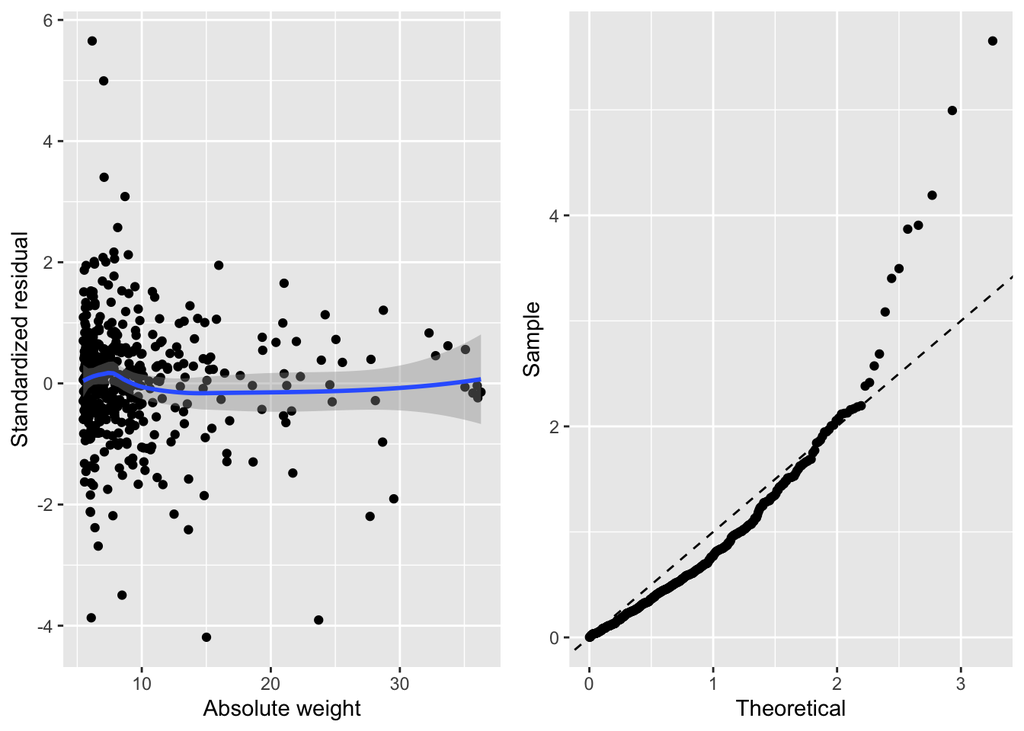

```
Estimated causal effect: -0.0836, standard error: 0.0251, p-value: 0.000883.
Estimated overdispersion variance: 2.45e-05, standard error: 1.8e-06, p-value: 5.13e-42.
ANOVA test: are the weights and residuals independent?
Analysis of Variance Table

Response: std.resids
                                                       Df Sum Sq Mean Sq
bs(weights, knots = quantile(weights, 1:df/(df + 1)))  25   29.7 1.18810
Residuals                                             418  413.3 0.98875
                                                      F value Pr(>F)
bs(weights, knots = quantile(weights, 1:df/(df + 1)))  1.2016 0.2319
Residuals
```

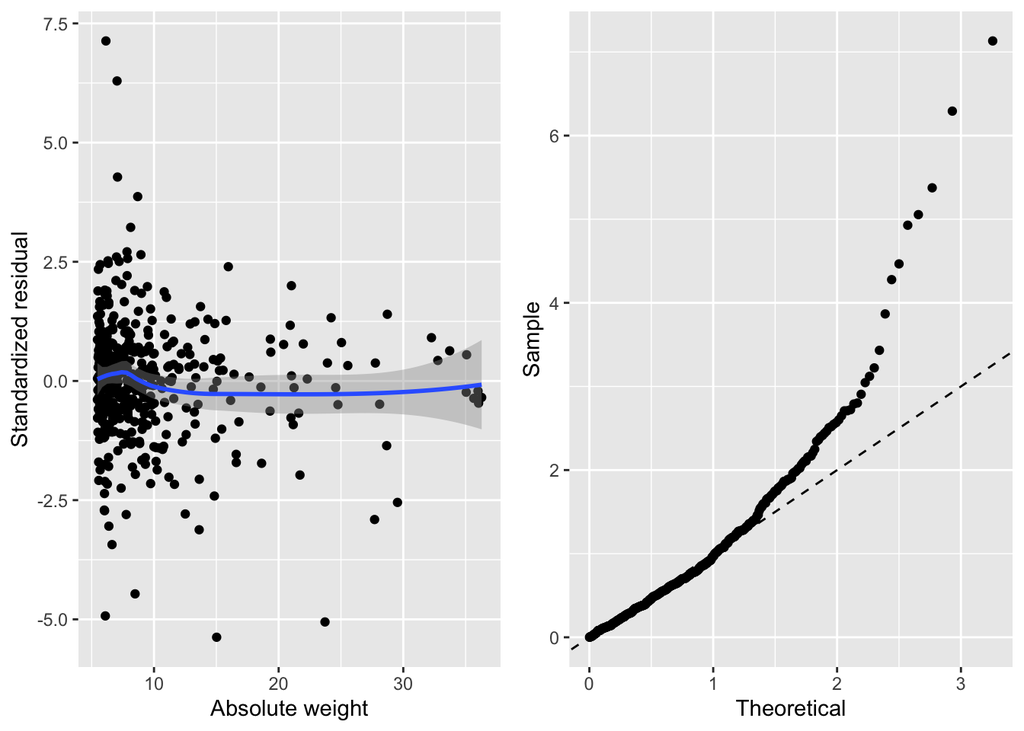

```
Estimated causal effect: -0.0623, standard error: 0.0204, p-value: 0.00222.
Estimated overdispersion variance: 1.44e-05, standard error: 1.21e-06, p-value: 7.73e-33.
ANOVA test: are the weights and residuals independent?
Analysis of Variance Table

Response: std.resids
                                                       Df Sum Sq Mean Sq
bs(weights, knots = quantile(weights, 1:df/(df + 1)))  25  45.17  1.8070
Residuals                                             418 666.62  1.5948
                                                      F value Pr(>F)
bs(weights, knots = quantile(weights, 1:df/(df + 1)))  1.1331 0.3008
Residuals
```

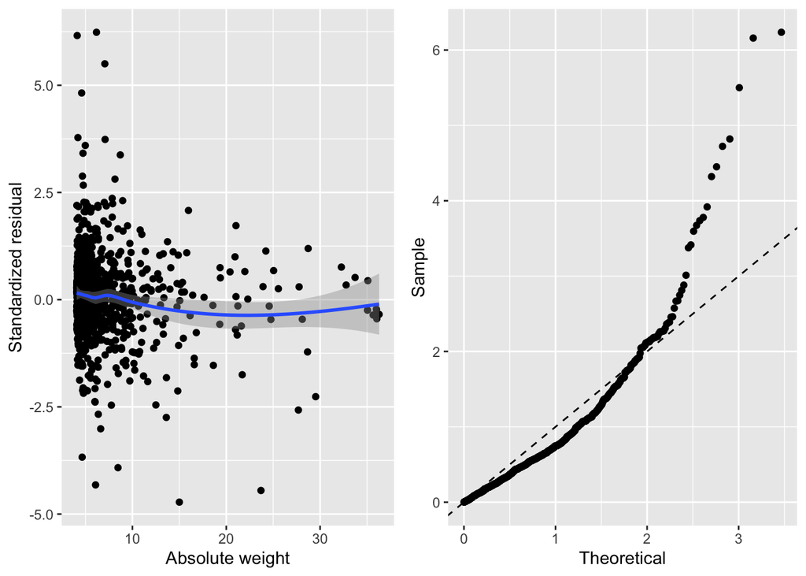

```
Estimated causal effect: -0.0564, standard error: 0.0209, p-value: 0.00702.
Estimated overdispersion variance: 1.95e-05, standard error: 1e-06, p-value: 3.89e-84.
ANOVA test: are the weights and residuals independent?
Analysis of Variance Table

Response: std.resids
                                                       Df Sum Sq Mean Sq
bs(weights, knots = quantile(weights, 1:df/(df + 1)))  50     67 1.33999
Residuals                                             898    881 0.98107
                                                      F value  Pr(>F)
bs(weights, knots = quantile(weights, 1:df/(df + 1)))  1.3658 0.04954 *
Residuals
---
Signif. codes:  0 '***' 0.001 '**' 0.01 '*' 0.05 '.' 0.1 ' ' 1
```

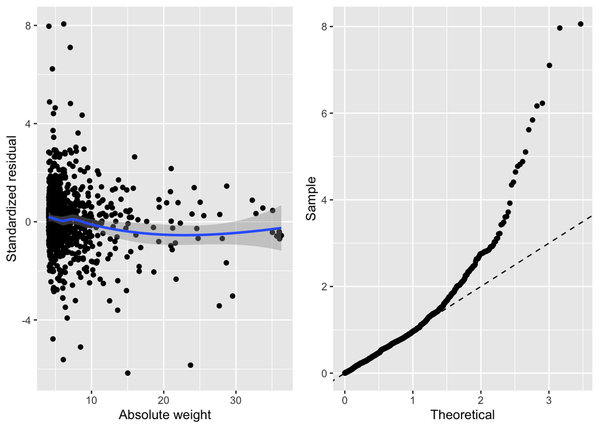

```
Estimated causal effect: -0.043, standard error: 0.0166, p-value: 0.00952.
Estimated overdispersion variance: 1.07e-05, standard error: 6.41e-07, p-value: 3.09e-62.
ANOVA test: are the weights and residuals independent?
Analysis of Variance Table

Response: std.resids
                                                       Df  Sum Sq Mean Sq
bs(weights, knots = quantile(weights, 1:df/(df + 1)))  50  101.51  2.0302
Residuals                                             898 1490.35  1.6596
                                                      F value Pr(>F)
bs(weights, knots = quantile(weights, 1:df/(df + 1)))  1.2233 0.1421
Residuals
```

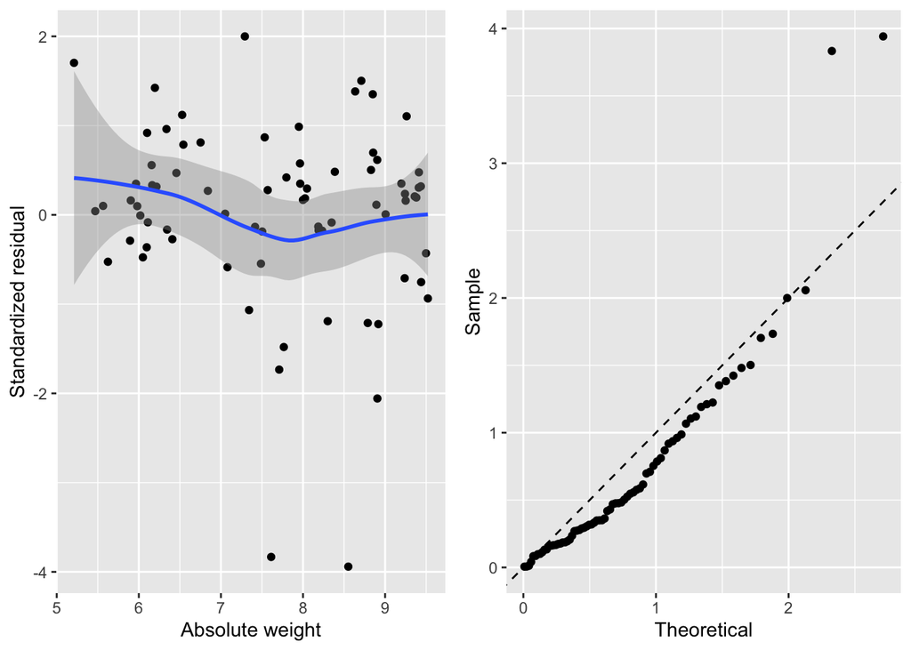

```
Estimated causal effect: -0.0587, standard error: 0.0235, p-value: 0.0123.
Estimated overdispersion variance: 2.45e-05, standard error: 4.38e-06, p-value: 2.4e-08.
ANOVA test: are the weights and residuals independent?
Analysis of Variance Table

Response: std.resids
                                                      Df Sum Sq Mean Sq F value
bs(weights, knots = quantile(weights, 1:df/(df + 1)))  7  6.094 0.87061  0.8592
Residuals                                             68 68.906 1.01332
                                                      Pr(>F)
bs(weights, knots = quantile(weights, 1:df/(df + 1))) 0.5431
Residuals
diagonal element is zero
[1] 2
diagonal element is zero
[1] 2
diagonal element is zero
[1] 2
```

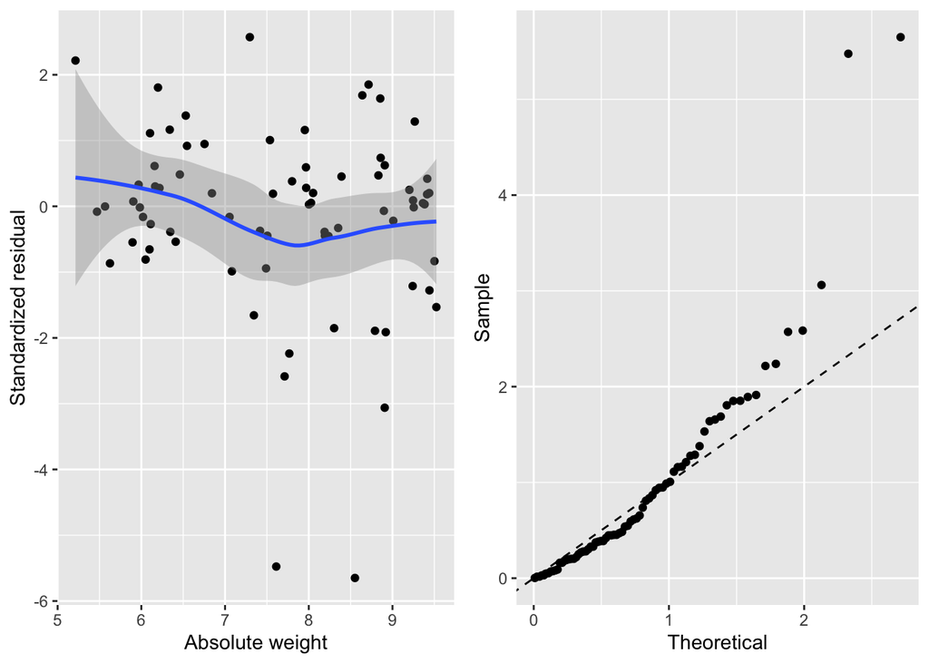

```
Estimated causal effect: -0.0303, standard error: 0.0175, p-value: 0.0831.
Estimated overdispersion variance: 1.17e-05, standard error: 2.47e-06, p-value: 1.96e-06.
ANOVA test: are the weights and residuals independent?
Analysis of Variance Table

Response: std.resids
                                                      Df  Sum Sq Mean Sq
bs(weights, knots = quantile(weights, 1:df/(df + 1)))  7  15.195  2.1707
Residuals                                             68 130.233  1.9152
                                                      F value Pr(>F)
bs(weights, knots = quantile(weights, 1:df/(df + 1)))  1.1334 0.3529
Residuals
```

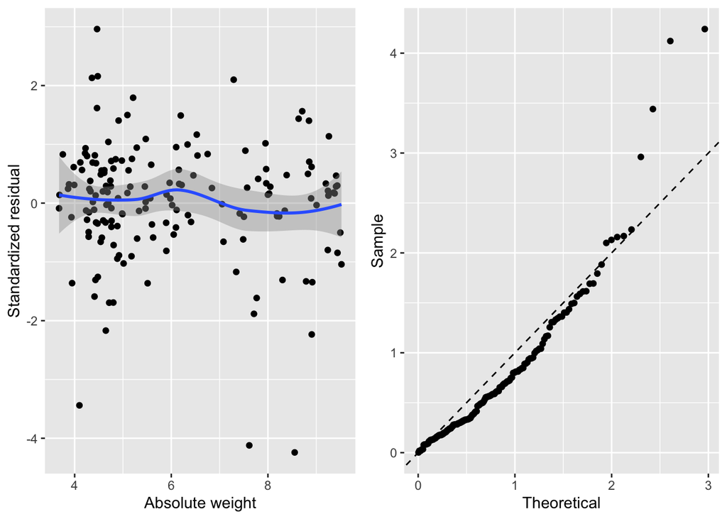

```
Estimated causal effect: -0.0522, standard error: 0.0186, p-value: 0.00496.
Estimated overdispersion variance: 2.12e-05, standard error: 2.6e-06, p-value: 3.82e-16.
ANOVA test: are the weights and residuals independent?
Analysis of Variance Table

Response: std.resids
                                                       Df  Sum Sq Mean Sq
bs(weights, knots = quantile(weights, 1:df/(df + 1)))  11   9.357 0.85062
Residuals                                             153 154.643 1.01074
                                                      F value Pr(>F)
bs(weights, knots = quantile(weights, 1:df/(df + 1)))  0.8416 0.5989
Residuals
```

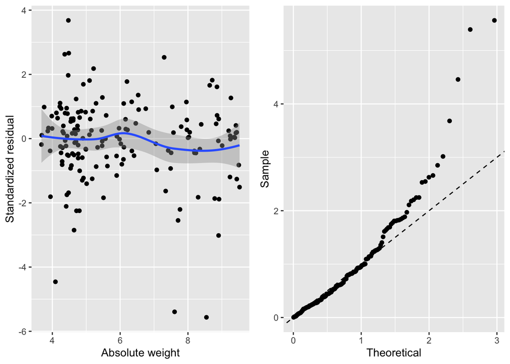

```
Estimated causal effect: -0.03, standard error: 0.015, p-value: 0.0454.
Estimated overdispersion variance: 1.22e-05, standard error: 1.72e-06, p-value: 1.45e-12.
ANOVA test: are the weights and residuals independent?
Analysis of Variance Table

Response: std.resids
                                                       Df  Sum Sq Mean Sq
bs(weights, knots = quantile(weights, 1:df/(df + 1)))  11  17.717  1.6107
Residuals                                             153 250.407  1.6366
                                                      F value Pr(>F)
bs(weights, knots = quantile(weights, 1:df/(df + 1)))  0.9841 0.4633
Residuals
```

```r
library(mr.raps)

fit_one <- function(arm, th, loss) {
  d <- ivs[[arm]][[th]]
  if (nrow(d) < 4) return(NULL)
  res <- try(fit_raps(b_exp = d$b.exp, b_out = d$b.out,
                      se_exp = d$se.exp, se_out = d$se.out,
                      loss = loss, over.dispersion = TRUE),
             silent = TRUE)
  if (inherits(res, "try-error")) {
    message("RAPS failed for ", arm, " / ", th, " / ", loss, ":\n",
            conditionMessage(attr(res, "condition")))
    return(NULL)
  }
  tidy_raps(res, arm = arm, threshold = th, loss = loss, n_iv = nrow(d))
}

raps_res <- tidyr::expand_grid(arm = names(ivs), th = names(thresholds),
                               loss = c("l2", "tukey")) |>
  purrr::pmap_dfr(function(arm, th, loss) fit_one(arm, th, loss))
```

```r
if (nrow(raps_res) == 0) {
  stop("All MR-RAPS fits failed — the messages above list what each interface reported.")
}
message("MR-RAPS interface used: ", paste(unique(raps_res$interface), collapse = ", "))
write_csv(raps_res, pp(cfg$paths$out, "raps_results.csv"))

raps_res |>
  select(arm, threshold, method, n_iv, b, se, lci, uci, pval, tau2, interface) |>
  arrange(arm, threshold, method) |>
  kable(caption = "MR-RAPS. tau2 is the estimated variance of horizontal pleiotropic effects; a large value with a stable beta indicates balanced pleiotropy.",
        digits = 4) |>
  kable_styling(full_width = FALSE)
```

MR-RAPS. tau2 is the estimated variance of horizontal pleiotropic effects; a large value with a stable beta indicates balanced pleiotropy.

| arm | threshold | method | n_iv | b | se | lci | uci | pval | tau2 | interface |
| --- | --- | --- | --- | --- | --- | --- | --- | --- | --- | --- |
| overlap-free | 5e-5 | MR-RAPS (l2) | 164 | -0.0522 | 0.0186 | -0.0887 | -0.0158 | 0.0050 | 0 | mr.raps(data.frame) |
| overlap-free | 5e-5 | MR-RAPS (tukey) | 164 | -0.0300 | 0.0150 | -0.0593 | -0.0006 | 0.0454 | 0 | mr.raps(data.frame) |
| overlap-free | 5e-8 | MR-RAPS (l2) | 75 | -0.0587 | 0.0235 | -0.1048 | -0.0127 | 0.0123 | 0 | mr.raps(data.frame) |
| overlap-free | 5e-8 | MR-RAPS (tukey) | 75 | -0.0303 | 0.0175 | -0.0645 | 0.0040 | 0.0831 | 0 | mr.raps(data.frame) |
| overlapping | 5e-5 | MR-RAPS (l2) | 948 | -0.0564 | 0.0209 | -0.0974 | -0.0154 | 0.0070 | 0 | mr.raps(data.frame) |
| overlapping | 5e-5 | MR-RAPS (tukey) | 948 | -0.0430 | 0.0166 | -0.0754 | -0.0105 | 0.0095 | 0 | mr.raps(data.frame) |
| overlapping | 5e-8 | MR-RAPS (l2) | 443 | -0.0836 | 0.0251 | -0.1329 | -0.0343 | 0.0009 | 0 | mr.raps(data.frame) |
| overlapping | 5e-8 | MR-RAPS (tukey) | 443 | -0.0623 | 0.0204 | -0.1023 | -0.0224 | 0.0022 | 0 | mr.raps(data.frame) |

[figure not shown]

```r
if (nrow(raps_res) > 0) {
  raps_res |>
    mutate(label = paste0(method, " @ ", threshold)) |>
    robust_mr_forest(title = "MR-RAPS: LDL-C -> heel eBMD, by threshold and loss") +
    facet_wrap(~arm)
}
```

## Reading it

- **Stable across thresholds** → weak-instrument bias is not the story, and the relaxed threshold in MR-APSS is safe.
- **Larger $|\beta|$ at 5e-8 than 5e-5** → the extra weak instruments carry proportionally more pleiotropy than signal.
- **$\tau^2$ substantially above zero** → real horizontal pleiotropy, but *balanced*. RAPS accommodates it; IVW’s standard errors would be too narrow.
- **`tukey` and `l2` disagree** → a few outlying variants are driving the estimate; prefer the robust fit and check which SNPs.

What RAPS *cannot* tell you is whether pleiotropy is correlated with instrument strength. If a shared factor drives both LDL-C and eBMD, RAPS is biased and will not warn you. That is what CAUSE and MR-APSS are for, and why the two classes are reported side by side in `robust_mr_summary.qmd`.